# Week2.HW.data

Bryan Aguiar

Sunday, April 05, 2015

## Week 2 Homework

The data file contains the systolic blood pressure (SBP), body size (QUET), age (AGE), and smoking history (SMK = 0 if nonsmoker, SMK = 1 if a current or previous smoker) for a hypothetical sample of 32 white males over 40 years old from the town of Angina.

```r
##Clear the environment
rm(list=ls())

##Turn off scientific notations for numbers
options(scipen = 999)

##Set locale
Sys.setlocale("LC_ALL", "English")
```

```
## [1] "LC_COLLATE=English_United States.1252;LC_CTYPE=English_United States.1252;LC_MONETARY=English_United States.1252;LC_NUMERIC=C;LC_TIME=English_United States.1252"
```

```r
##Set seed for reproducibility
set.seed(2345)

##Function for pi
plot.add.pi <- function(x, y, interval='prediction', level=0.95, regressionColor='red', ...) {
  xOrder  <- order(x)
    x       <- x[xOrder]
    y       <- y[xOrder]
        fit     <- lm(y ~ x, data=data.frame(x=x, y=y))
    newX    <- data.frame(x=jitter(x))
    fitPred <- predict.lm(fit, newdata=newX, interval=interval, level=level, ...)
    abline(lm(y ~ x), col=regressionColor)
    lines(newX$x, fitPred[,2], lty=2, ...)
    lines(newX$x, fitPred[,3], lty=2, ...)
}

##Function for ci
plot.add.ci <- function(x, y, interval='confidence', level=0.95, regressionColor='red', ...) {
  xOrder  <- order(x)
  x       <- x[xOrder]
    y       <- y[xOrder]
        fit     <- lm(y ~ x, data=data.frame(x=x, y=y))
    newX    <- data.frame(x=jitter(x))
    fitPred <- predict.lm(fit, newdata=newX, interval=interval, level=level, ...)
    #abline(lm(y ~ x), col=regressionColor)
    lines(newX$x, fitPred[,2], lty=2, ...)
    lines(newX$x, fitPred[,3], lty=2, ...)
}

DF<- read.csv("G:/Data/week2-HW-data.csv")
summary(DF)
```

```
##      Person           SBP             QUET            AGE
##  Min.   : 1.00   Min.   :120.0   Min.   :2.368   Min.   :41.00
##  1st Qu.: 8.75   1st Qu.:134.8   1st Qu.:3.022   1st Qu.:48.00
##  Median :16.50   Median :143.0   Median :3.381   Median :53.50
##  Mean   :16.50   Mean   :144.5   Mean   :3.441   Mean   :53.25
##  3rd Qu.:24.25   3rd Qu.:152.0   3rd Qu.:3.776   3rd Qu.:58.25
##  Max.   :32.00   Max.   :180.0   Max.   :4.637   Max.   :65.00
##       SMK
##  Min.   :0.0000
##  1st Qu.:0.0000
##  Median :1.0000
##  Mean   :0.5312
##  3rd Qu.:1.0000
##  Max.   :1.0000
```

## Exercise One and Two

Generate scatter diagrams for each of the following variable pairs. Using scatter diagrams #1, #3, and #4 that you generated above, use paper and pencil to roughly sketch a line that fits the data reasonably well. Use the homework forum to share your sketches and comment on the relationships described.

1. SPB (Y) vs. QUET (X)

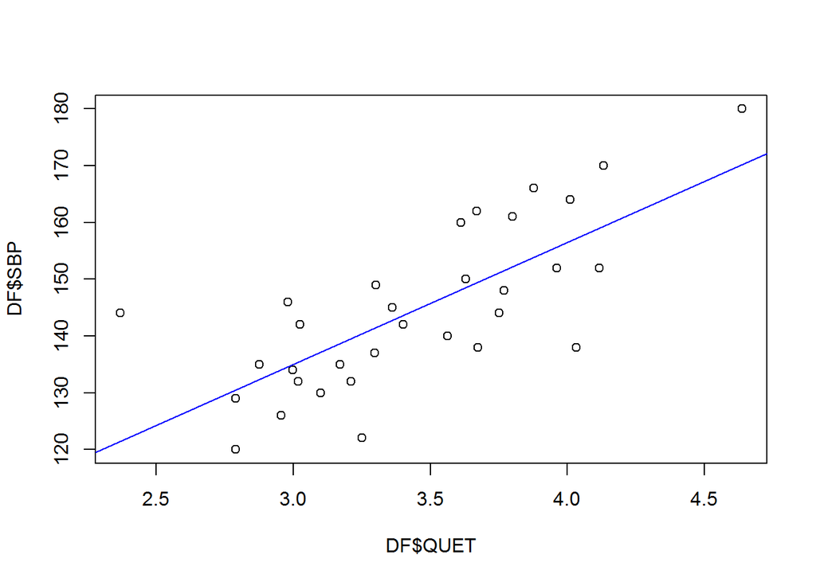

2. SBP (Y) vs. SMK (X)

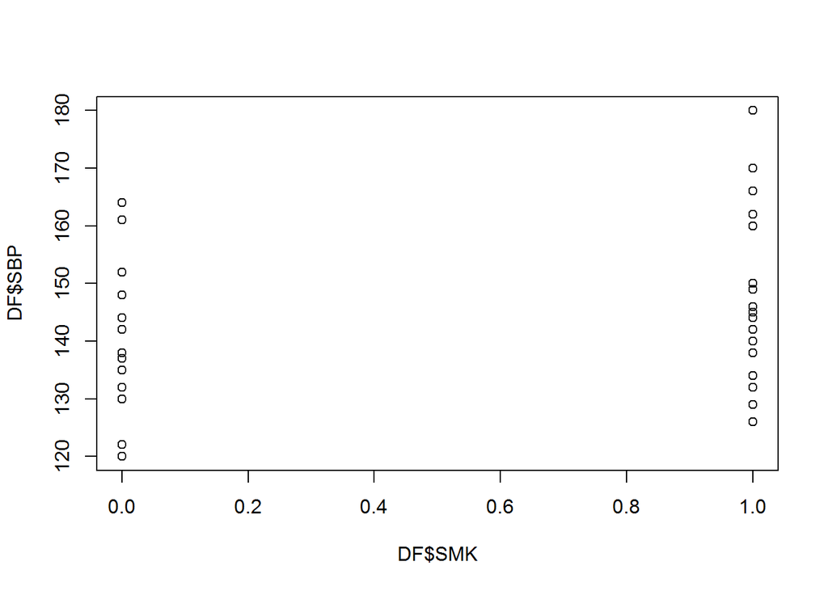

3. QUET (Y) vs. AGE (X)

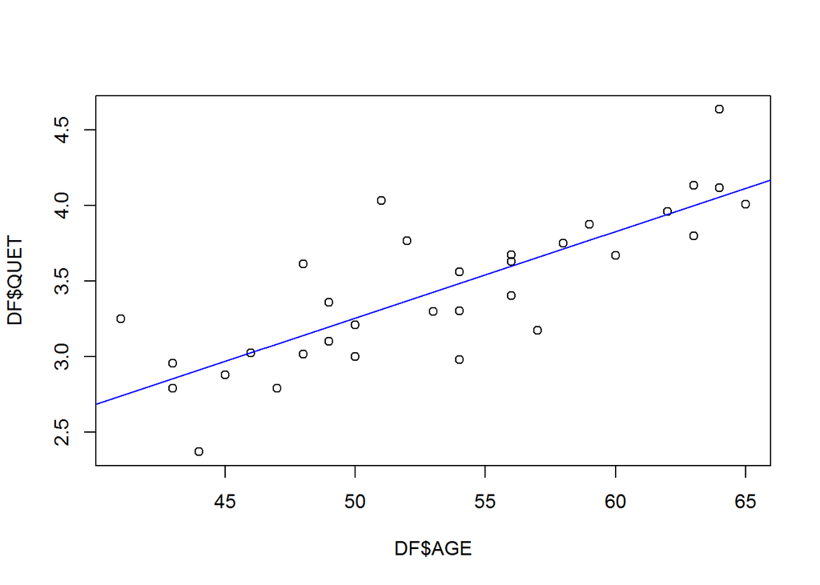

4. SBP (Y) vs. AGE (X)

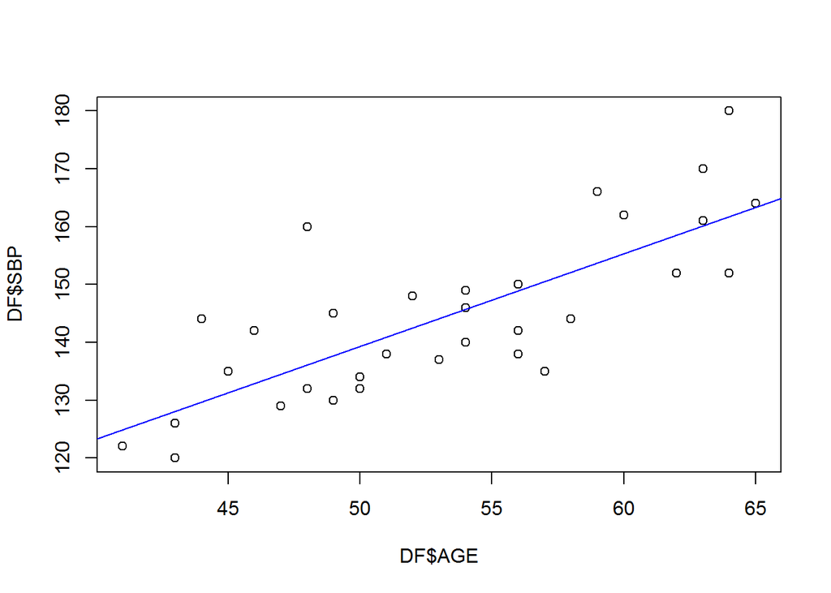

## Exercise Three

### Comparing Blood Pressure with Smoking History.

1. Determine the least-squares estimates of slope and intercept for the straight line regression of SBP (Y) on SMK (X).

```r
model01 <- lm(DF$SBP ~ DF$SMK)
coef(model01)
```

```
## (Intercept)      DF$SMK
##  140.800000    7.023529
```

2. Sketch the estimated regression line on the scatter diagram involving SBP and SMK.

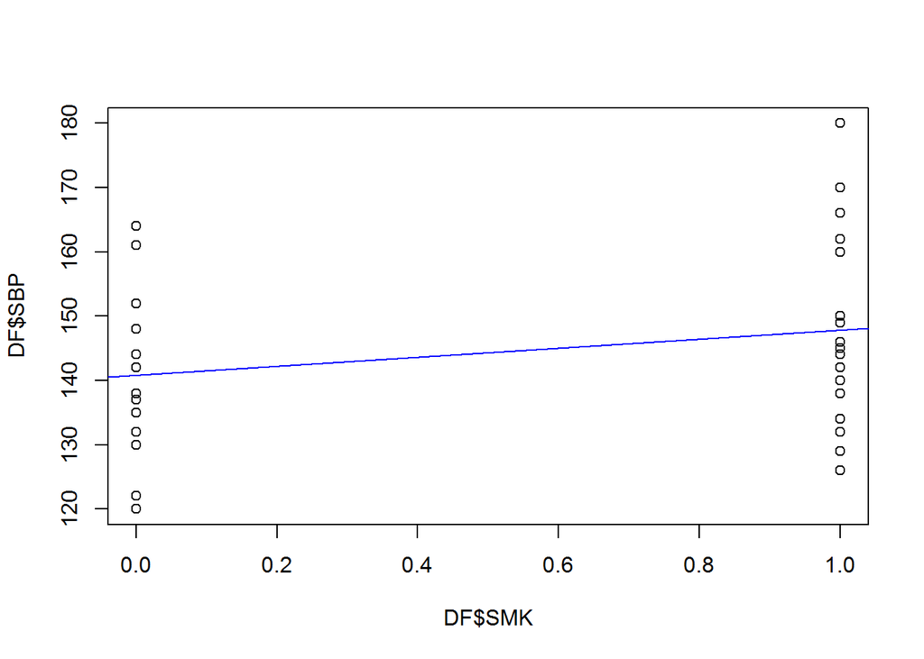

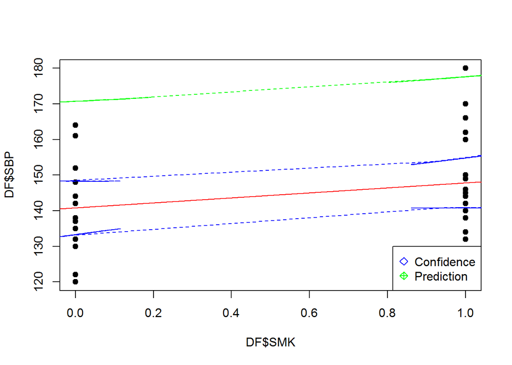

## Exercise Four

### Comparing Blood Pressure with Body Size

1. Determine the least-squares estimates of slope and intercept for the straight-line regression of SBP (Y) on QUET (X). Slope and intercept are:

```r
model02 <- lm(DF$SBP ~ DF$QUET)
coef(model02)
```

```
## (Intercept)     DF$QUET
##    70.57640    21.49167
```

2. Sketch the estimated regression line on the scatter diagram involving SBP and QUET.

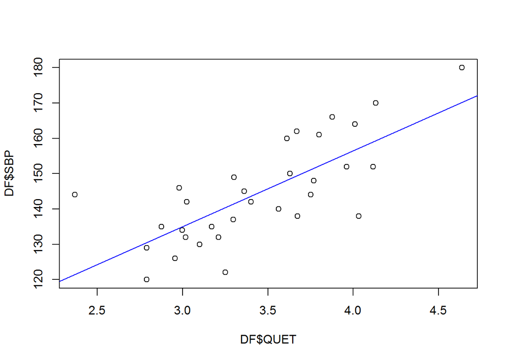

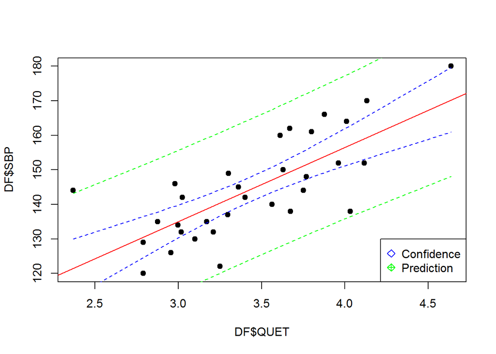